# Deriving an integrated CJK variant map

Alan Engel

27 September, 2024

```r
library(rlang)
library(tidyverse)
library(dplyr)
library(xslt)
library(tibble)
library(stringi)
library(viafr)
library(magrittr)
library(igraph)
library(rnaco)
```

This vignette describes a derivation of an integrated CJK variant map for name authority comparison.

## The Problem

At a previous devlopment stage, this package included tranformations using the NACO Authority Comparison Rules(Program for Cooperative Cataloging 2020), the Unihan Variants, and Traditional-Simplified transformation. But in testing these using the `cjkextractja` dataset obtained from the [NACO CJK Funnel References Project Guidelines](https://www.loc.gov/aba/pcc/naco/CJK/NACO-CJK-Funnel-References-Project-Guidelines.docx)(Program for Cooperative Cataloging 2019). (Please see the accompanying vignette) found Japanese characters whose normalization did not replicate that found in x400 elements of corresponding VIAF clusters. For example, the [VIAF cluster for Kawai, Ryūsuke](https://viaf.org/viaf/11309362/viaf.xml) contains the following two x400 elements.

```
<ns1:x400>
<ns1:datafield dtype="MARC21" ind1="1" ind2=" " tag="400">
<ns1:subfield code="a">川井竜介,</ns1:subfield>
<ns1:subfield code="d">1956-</ns1:subfield>
<ns1:normalized>巛丼尨介 1956</ns1:normalized>
</ns1:datafield>
<ns1:sources>
<ns1:s>LC</ns1:s>
<ns1:sid>LC|n 85367264</ns1:sid>
</ns1:sources>
</ns1:x400>
...
<ns1:x400>
<ns1:datafield dtype="MARC21" ind1="1" ind2=" " tag="400">
<ns1:subfield code="a">川井龍介,</ns1:subfield>
<ns1:subfield code="d">1956-</ns1:subfield>
<ns1:normalized>巛丼尨介 1956</ns1:normalized>
</ns1:datafield>
<ns1:sources>
<ns1:s>LC</ns1:s>
<ns1:sid>LC|n 85367264</ns1:sid>
</ns1:sources>
</ns1:x400>
```

In this example, the two name strings 川井竜介 and 川井龍介 are transformed to 巛丼尨介. Of the three characters that are transformed for each of these two strings, the first two could be transformed by the viaf_cjk_transform() function of this package. The third character was not yet transformed.

| original | x400 normalization |  |
| --- | --- | --- |
| 川 (U+5DDD) | 巛 (U+5DDB) |  |
| 井 (U+4E95) | 丼 (U+4E3C) |  |
| 竜 (U+7ADC) | 尨 (U+5C28) |  |
| 龍 (U+9F8D) | 尨 (U+5C28) |  |

The characters 川 (U+5DDD) and 巛 (U+5DDB) both mean “river”. The former is a [member of Japanese Joyo Kanji](https://util.unicode.org/UnicodeJsps/character.jsp?a=5DDD), but the [latter is not](https://util.unicode.org/UnicodeJsps/character.jsp?a=5DDB). They are semantic variants of each other.

The character [井 (U+4E95)](https://util.unicode.org/UnicodeJsps/character.jsp?a=4E95) means “well” while [丼 (U+4E3C)](https://util.unicode.org/UnicodeJsps/character.jsp?a=4E3C) has the additional meaning of “bowl of food”. This makes them specialized semantic variants. They are both Joyo Kanji.

The characters [竜 (U+7ADC)](https://util.unicode.org/UnicodeJsps/character.jsp?a=7ADC), [龍 (U+9F8D)](https://util.unicode.org/UnicodeJsps/character.jsp?a=9F8D) and [尨 (U+5C28)](https://util.unicode.org/UnicodeJsps/character.jsp?a=5C28) are more complicated. Meaning “dragon”, 龍 is neither a Joyo Kanji nor a simplified Kanji. Its simplified variant is [龙 (U+9F99)](https://util.unicode.org/UnicodeJsps/character.jsp?a=9F99). Its Jinmeiyo Kanji variant is the character [竜 (U+7ADC)](https://util.unicode.org/UnicodeJsps/character.jsp?a=7ADC), which is a Joyo Kanji. These dragons’ link to [尨 (U+5C28)](https://util.unicode.org/UnicodeJsps/character.jsp?a=5C28) is via the MJ Shukutai Map, which contains MJ element below. This element indicates that 尨 is recognized as valid for family registries and the characters 龍 and 竜 are related to it by dictionaries or other sources. It doesn’t have a simplified variant, but does have the semantic variant [狵 U+72F5](https://util.unicode.org/UnicodeJsps/character.jsp?a=72F5).

```
<縮退候補情報>
  <MJ文字図形名>MJ034246</MJ文字図形名> <!-- MJ code -->
  <法務省戸籍法関連通達-通知>
    <戸籍統一文字情報_親字-正字 ホップ数="1"> <!-- Unified koseki, 1 'hop' -->
      <JIS_X_0213情報>
        <面区点位置>1-53-88</面区点位置>
        <対応UCS>U+5C28</対応UCS>
      </JIS_X_0213情報>
    </戸籍統一文字情報_親字-正字>
    <戸籍統一文字情報_親字-正字 ホップ数="2"> <!-- Unified koseki, 2 'hops' -->
      <JIS_X_0213情報>
        <面区点位置>1-53-88</面区点位置>
        <対応UCS>U+5C28</対応UCS>
      </JIS_X_0213情報>
    </戸籍統一文字情報_親字-正字>
  </法務省戸籍法関連通達-通知>
  <辞書類等による関連字> <!-- related characters based on dictionaries, etc. -->
    <JIS_X_0213情報>
      <面区点位置>1-46-21</面区点位置>
      <対応UCS>U+7ADC</対応UCS>
    </JIS_X_0213情報>
    <JIS_X_0213情報>
      <面区点位置>1-46-22</面区点位置>
      <対応UCS>U+9F8D</対応UCS>
    </JIS_X_0213情報>
  </辞書類等による関連字>
</縮退候補情報>
```

A more troublesome example is the x400 normalization found in the record below. This record comes from personal name authority records that were developed by the NACO CJK Funnel References Project(Program for Cooperative Cataloging 2019) as a source of testing and development data. This data were used to obtain names and corresponding normalizations from the Virtual International Authority Files (VIAF). This particular record is from the [VIAF cluster for Nagayo, Sensai, 1838-1902](https://viaf.org/viaf/11173352/viaf.xml).

```
<ns1:x400>
<ns1:datafield dtype="MARC21" ind1="1" ind2=" " tag="400">
<ns1:subfield code="a">長与専斎,</ns1:subfield>
<ns1:subfield code="d">1838-1902</ns1:subfield>
<ns1:normalized>長与专亝 1838 1902</ns1:normalized>
</ns1:datafield>
<ns1:sources>
<ns1:s>LC</ns1:s>
<ns1:sid>LC|n 81105244</ns1:sid>
</ns1:sources>
</ns1:x400>
```

| original | x400 normalization |  |
| --- | --- | --- |
| 長 (U+9577) | 長 (U+9577) |  |
| 与 (U+4E0E) | 与 (U+4E0E) |  |
| 専 (U+5C02) | 专 (U+4E13) |  |
| 斎 (U+658E) | 亝 (U+4E9D) |  |

This normalized form contains Japanese and simplified Chinese characters. The characters [長 (U+9577)](https://util.unicode.org/UnicodeJsps/character.jsp?a=9577), [与 (U+4E0E)](https://util.unicode.org/UnicodeJsps/character.jsp?a=4E0E), [专 (U+4E13)](https://util.unicode.org/UnicodeJsps/character.jsp?a=4E13), and [亝 (U+4E9D)](https://util.unicode.org/UnicodeJsps/character.jsp?a=4E9D) 長 is a traditional Chinese character and also a Japanese character taught in the first grade. 与 is shared by Japanese, traditional Chinese and simplified Chinese. 专 is simplified Chinese and not used in Japanese. 亝 is Japanese but not a Joyo Kanji.

One possible explanation for this mix is that variant clusters derived from combining the Unihan variants with variants derived from the MojiJoho “shrink map” are used for normalization, with each cluster being represented by the character with the numerically smallest Unicode code point. After all, the normalized forms are used for algorithmicly comparing names and not necessarily for human viewing. This possiblity is explored below.

## Normalization scheme

The normalization scheme below combines Unihan variants and Moji Joho variants into a single graph and clusters determined using the walktrap algorithm in R package igraph (Csárdi et al. 2024). Representative ideographs are selected from each cluster based on the Unihan database property kUnihanCore2020 (Lunde 2019), one for each of the IRG sources Japan (J), PRC (G), and the Taipei Computing Association (T). The representative ideograph becomes the “normalized” ideograph. Users can select which of the three IRG sources they wish to be favored.

The normalization scheme further prioritizes by educational level as determined by the grade level at which the ideograph is taught in Japan, China and Taiwan, by the number of strokes in the ideograph, and finally by the numerical sequence of the ideograph’s Unicode code point.

All ideographs in the combined Unihan and Moji Joho sets are assigned precedence values so that no ideograph is excluded. Because the representative ideograph is merely a label for it’s respective cluster, its analytical behavior should be that of its cluster and analytical behavior should not differ depending on J, G or T preference of the user.

### Data frames from Unihan and Moji Joho variants

The function `igraph::graph_from_data_frame()` accept as input data frames with the columns ‘from’, ‘to’ and ‘relation’. The code chunk below makes a graph from each variant set and then combines them.

```r
unihandf <- unihanVariants %>% filter(varianttype != "kSpoofingVariant") %>%
    mutate(from = ucsindex, to=ucsvariant, relation=varianttype) %>%
    select(from,to,relation)

mojidf <- mojiMapdf %>%
        mutate(
          from = as.hexmode(stringi::stri_match_first(from,regex = "(?:U[+])([A-F0-9]++)")[,2]),
          to = as.hexmode(stringi::stri_match_first(to,regex = "(?:U[+])([A-F0-9]++)")[,2]),
          relation = as.factor(relation)
        ) %>%
        select(from,to,relation)

gunihan <- igraph::graph_from_data_frame(unihandf,directed = TRUE, vertices = NULL)
gmoji <- igraph::graph_from_data_frame(mojidf,directed = TRUE, vertices = NULL)

gc <- gunihan + gmoji
```

### Use walktrap algorithm to compute clusters.

```r
wc <- cluster_walktrap(gc, steps=4)

clustpick <- tibble(ucs=V(gc)$name, edges=as.integer(degree(gc, mode="all")),
            membership=membership(wc)) %>%
            mutate(ucs = as.hexmode(ucs))
summary(clustpick$edges)
```

```
##    Min. 1st Qu.  Median    Mean 3rd Qu.    Max.
##   1.000   1.000   2.000   2.461   2.000  73.000
```

The result `clustpick` is a tibble that lists the number of edges and assigned membership cluster for 29556 ideographs grouped into 8088 clusters. The ideographs have edge connections to as many as 73 other ideographs with the median number of edges being 2.

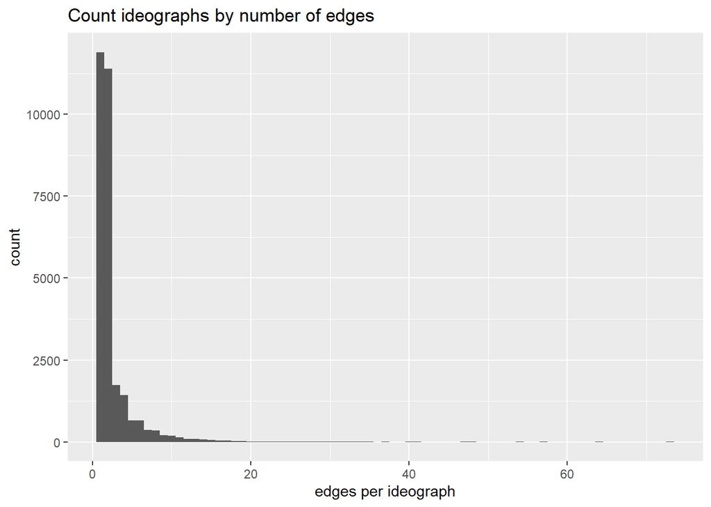

```r
library(ggpubr)
ggplot(clustpick , aes(x = edges)) +
  geom_histogram(binwidth=1) +
  labs(title="Count ideographs by number of edges") +
  labs(x = "edges per ideograph")
```

The code chunk below looks at the sizes of these ideograph clusters.

```r
clustersizes <- clustpick %>% group_by(membership) %>%
    mutate(n = n()) %>%
    ungroup() %>%
    select(membership, n)

cssum <- summary(clustersizes$n)
```

The clusters range in size from 1 up to 97 ideographs with the median being 4. The histogram below shows the distribution of cluster sizes.

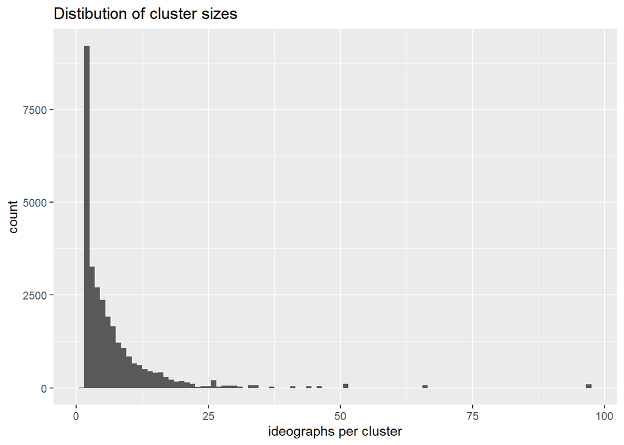

```r
ggplot(clustersizes , aes(x = n)) +
  geom_histogram(binwidth=1) +
  labs(title="Distibution of cluster sizes") +
  labs(x = "ideographs per cluster")
```

### Adding preference rankings

The code chunk below produces a table of preference rankings for the Japanese preference. It first calculates a precedence score, jaPrec, for each ideograph, and then determines the minimum score for each membership cluster. The precedence score is kept in the final table for diagnostic purposes.

```r
#jct <- rnaco::jctPrecedence
jct <- jctPrecedence

jaSet <- clustpick %>%
    dplyr::inner_join(jct, by=join_by(ucs==ucs)) %>% # filter(ucs == as.hexmode(0x08303))
    mutate(
        jaPrec =  num((jCoreRank*1000 + jpRank*100 + kTotalStrokes) + as.double(as.integer(ucs))/as.double(1000000),
                digits = 6, notation="dec")
    ) %>%
    select(ucs,edges,membership,jaPrec) %>%
    group_by(membership) %>%
    mutate(jaPick = min(jaPrec)) %>%
    ungroup() %>% unique()
jaSet
```

```
## # A tibble: 29,555 × 5
##    ucs       edges membership      jaPrec      jaPick
##    <hexmode> <int> <membrshp>   <dec:.6!>   <dec:.6!>
##  1 3400          2   92       8905.013312 1705.019992
##  2 3405          2   83       8902.013317 1104.020116
##  3 342b          2 2668       8906.013355 1704.020982
##  4 342e          3   15       8913.013358 1710.034928
##  5 342f          2  127       8917.013359 1102.020154
##  6 3431          3    3       8905.013361 1108.038632
##  7 3434          2 1746       8905.013364 1919.025856
##  8 3435          2 2615       8905.013365 1716.020754
##  9 3437          2  749       8905.013367 2715.032629
## 10 3439          3  259       8906.013369 2913.024894
## # ℹ 29,545 more rows
```

```r
jaTbl <- jaSet %>% select(ucs,edges,membership,jaPrec,jaPick) %>%
    dplyr::inner_join(select(jaSet,ucs,jaPrec), by=join_by(jaPick==jaPrec)) %>%
    dplyr::rename(c(ucs = "ucs.x",ucsjppick="ucs.y")) %>%
    select(ucs,edges,membership,jaPrec,ucsjppick)
jaTbl
```

```
## # A tibble: 29,555 × 5
##    ucs       edges membership      jaPrec ucsjppick
##    <hexmode> <int> <membrshp>   <dec:.6!> <hexmode>
##  1 3400          2   92       8905.013312 4e18
##  2 3405          2   83       8902.013317 4e94
##  3 342b          2 2668       8906.013355 51f6
##  4 342e          3   15       8913.013358 8870
##  5 342f          2  127       8917.013359 4eba
##  6 3431          3    3       8905.013361 96e8
##  7 3434          2 1746       8905.013364 6500
##  8 3435          2 2615       8905.013365 5112
##  9 3437          2  749       8905.013367 7f75
## 10 3439          3  259       8906.013369 613e
## # ℹ 29,545 more rows
```

Then do the same for the PRC and Taiwan sources.

```r
zhSet <- clustpick %>%
    dplyr::inner_join(jct, by=join_by(ucs==ucs)) %>% # filter(ucs == as.hexmode(0x08303))
    mutate(
        zhPrec =  num((gCoreRank*1000 + zhRank*100 + kTotalStrokes) + as.double(as.integer(ucs))/as.double(1000000),
                digits = 6, notation="dec")
    ) %>%
    select(ucs,edges,membership,zhPrec) %>%
    group_by(membership) %>%
    mutate(zhPick = min(zhPrec)) %>%
    ungroup() %>% unique()
zhSet
```

```
## # A tibble: 29,555 × 5
##    ucs       edges membership      zhPrec      zhPick
##    <hexmode> <int> <membrshp>   <dec:.6!>   <dec:.6!>
##  1 3400          2   92       8905.013312 1305.019992
##  2 3405          2   83       8902.013317 1104.020116
##  3 342b          2 2668       8906.013355 1904.020982
##  4 342e          3   15       8913.013358 1410.034928
##  5 342f          2  127       8917.013359 1102.020154
##  6 3431          3    3       8905.013361 1108.038632
##  7 3434          2 1746       8905.013364 1919.025856
##  8 3435          2 2615       8905.013365 1916.020754
##  9 3437          2  749       8905.013367 7106.021527
## 10 3439          3  259       8906.013369 4905.020193
## # ℹ 29,545 more rows
```

```r
zhTbl <- zhSet %>% select(ucs,edges,membership,zhPrec,zhPick) %>%
    dplyr::inner_join(select(zhSet,ucs,zhPrec), by=join_by(zhPick==zhPrec)) %>%
    dplyr::rename(c(ucs = "ucs.x",ucszhpick="ucs.y")) %>%
    select(ucs,zhPrec,ucszhpick)
zhTbl
```

```
## # A tibble: 29,555 × 3
##    ucs            zhPrec ucszhpick
##    <hexmode>   <dec:.6!> <hexmode>
##  1 3400      8905.013312 4e18
##  2 3405      8902.013317 4e94
##  3 342b      8906.013355 51f6
##  4 342e      8913.013358 8870
##  5 342f      8917.013359 4eba
##  6 3431      8905.013361 96e8
##  7 3434      8905.013364 6500
##  8 3435      8905.013365 5112
##  9 3437      8905.013367 5417
## 10 3439      8906.013369 4ee1
## # ℹ 29,545 more rows
```

```r
twSet <- clustpick %>%
    dplyr::inner_join(jct, by=join_by(ucs==ucs)) %>% # filter(ucs == as.hexmode(0x08303))
    mutate(
        twPrec =  num((tCoreRank*1000 + twRank*100 + kTotalStrokes) + as.double(as.integer(ucs))/as.double(1000000),
                digits = 6, notation="dec")
    ) %>%
    select(ucs,edges,membership,twPrec) %>%
    group_by(membership) %>%
    mutate(twPick = min(twPrec)) %>%
    ungroup() %>% unique()

twTbl <- twSet %>% select(ucs,edges,membership,twPrec,twPick) %>%
    dplyr::inner_join(select(twSet,ucs,twPrec), by=join_by(twPick==twPrec)) %>%
    dplyr::rename(c(ucs = "ucs.x",ucstwpick="ucs.y")) %>%
    select(ucs,twPrec,ucstwpick)

twTbl
```

```
## # A tibble: 29,555 × 3
##    ucs            twPrec ucstwpick
##    <hexmode>   <dec:.6!> <hexmode>
##  1 3400      8905.013312 4e18
##  2 3405      8902.013317 4e94
##  3 342b      8906.013355 51f6
##  4 342e      8913.013358 8870
##  5 342f      8917.013359 4eba
##  6 3431      8905.013361 96e8
##  7 3434      8905.013364 6500
##  8 3435      8905.013365 5112
##  9 3437      8905.013367 7f75
## 10 3439      8906.013369 613e
## # ℹ 29,545 more rows
```

And combine them.

```r
jazhtwMap <- jaTbl %>%
    dplyr::inner_join(zhTbl, by=join_by(ucs == ucs))  %>%
    dplyr::inner_join(twTbl, by=join_by(ucs == ucs))

jazhtwMap
```

```
## # A tibble: 29,555 × 9
##    ucs   edges membership      jaPrec ucsjppick      zhPrec ucszhpick      twPrec
##    <hex> <int> <membrshp>   <dec:.6!> <hexmode>   <dec:.6!> <hexmode>   <dec:.6!>
##  1 3400      2   92       8905.013312 4e18      8905.013312 4e18      8905.013312
##  2 3405      2   83       8902.013317 4e94      8902.013317 4e94      8902.013317
##  3 342b      2 2668       8906.013355 51f6      8906.013355 51f6      8906.013355
##  4 342e      3   15       8913.013358 8870      8913.013358 8870      8913.013358
##  5 342f      2  127       8917.013359 4eba      8917.013359 4eba      8917.013359
##  6 3431      3    3       8905.013361 96e8      8905.013361 96e8      8905.013361
##  7 3434      2 1746       8905.013364 6500      8905.013364 6500      8905.013364
##  8 3435      2 2615       8905.013365 5112      8905.013365 5112      8905.013365
##  9 3437      2  749       8905.013367 7f75      8905.013367 5417      8905.013367
## 10 3439      3  259       8906.013369 613e      8906.013369 4ee1      8906.013369
## # ℹ 29,545 more rows
## # ℹ 1 more variable: ucstwpick <hexmode>
```

Create transliteration rules for stringi::stri_trans_general().

```r
jztTranslitRules <- jazhtwMap %>%
    mutate(from = intToUtf8(as.integer(ucs), multiple = TRUE),
        to.JA = intToUtf8(as.integer(ucsjppick), multiple = TRUE),
        rule.JA = paste0(from," > ",to.JA ," ;",sep="" )) %>%
    mutate(from = intToUtf8(as.integer(ucs), multiple = TRUE),
        to.ZH = intToUtf8(as.integer(ucszhpick), multiple = TRUE),
        rule.ZH = paste0(from," > ",to.ZH," ;",sep="" )) %>%
    mutate(from = intToUtf8(as.integer(ucs), multiple = TRUE),
        to.TW = intToUtf8(as.integer(ucstwpick), multiple = TRUE),
        rule.TW = paste0(from," > ",to.TW," ;",sep="" )) %>%
    select(ucs,membership, from,to.JA,rule.JA,to.ZH,rule.ZH,to.TW,rule.TW)
jztTranslitRules
```

```
## # A tibble: 29,555 × 9
##    ucs       membership from  to.JA rule.JA   to.ZH rule.ZH   to.TW rule.TW
##    <hexmode> <membrshp> <chr> <chr> <chr>     <chr> <chr>     <chr> <chr>
##  1 3400        92       㐀    丘    㐀 > 丘 ; 丘    㐀 > 丘 ; 丘    㐀 > 丘 ;
##  2 3405        83       㐅    五    㐅 > 五 ; 五    㐅 > 五 ; 五    㐅 > 五 ;
##  3 342b      2668       㐫    凶    㐫 > 凶 ; 凶    㐫 > 凶 ; 凶    㐫 > 凶 ;
##  4 342e        15       㐮    衰    㐮 > 衰 ; 衰    㐮 > 衰 ; 衰    㐮 > 衰 ;
##  5 342f       127       㐯    人    㐯 > 人 ; 人    㐯 > 人 ; 人    㐯 > 人 ;
##  6 3431         3       㐱    雨    㐱 > 雨 ; 雨    㐱 > 雨 ; 雨    㐱 > 雨 ;
##  7 3434      1746       㐴    攀    㐴 > 攀 ; 攀    㐴 > 攀 ; 攀    㐴 > 攀 ;
##  8 3435      2615       㐵    儒    㐵 > 儒 ; 儒    㐵 > 儒 ; 儒    㐵 > 儒 ;
##  9 3437       749       㐷    罵    㐷 > 罵 ; 吗    㐷 > 吗 ; 罵    㐷 > 罵 ;
## 10 3439       259       㐹    愾    㐹 > 愾 ; 仡    㐹 > 仡 ; 愾    㐹 > 愾 ;
## # ℹ 29,545 more rows
```

# References

Csárdi, Gábor, Tamás Nepusz, Vincent Traag, Szabolcs Horvát, Fabio Zanini, Daniel Noom, and Kirill Müller. 2024. *igraph: Network Analysis and Visualization in r*. https://doi.org/10.5281/zenodo.7682609.

Lunde, Ken. 2019. “New Unihan Database Property: kUnihanCore2020.” Unicode® Technical Committee. https://www.unicode.org/L2/L2019/19388-unihan-core-2020.pdf.

Program for Cooperative Cataloging. 2019. “NACO CJK Funnel References Project Guidelines.” May 2019. https://www.loc.gov/aba/pcc/naco/CJK.html.

———. 2020. “Authority File Comparison Rules (NACO Normalization).” April 9, 2020. https://www.loc.gov/aba/pcc/naco/normrule-2.html.